[figure not shown]

[]

# Introduction

In alternative splicing ananlysis of RNASeq data, one popular approach is to first identify gene features (e.g. exons or junctions) significantly associated with splicing using methods such as DEXSeq [@Anders2012] or JunctionSeq [@Hartley2016], and then perform pathway analysis based on the list of genes associated with the significant gene features.

For DEXSeq results, we use *gene features* to refers to non-overlapping exon counting bins [@Anders2012, Figure 1], while for JunctionSeq results, *gene features* refers to non-overlapping exon or splicing junction counting bins.

A major challenge is that without explicit adjustment, pathways analysis would be biased toward pathways that include genes with a large number of gene features, because these genes are more likely to be selected as “significant genes” in pathway analysis.

PathwaySplice is an R package that falicitate the folowing analysis:

1. Performing pathway analysis that explicitly adjusts for the number of exons or junctions associated with each gene;
2. Visualizing selection bias due to different number of exons or junctions for each gene and formally tests for presence of bias using logistic regression;
3. Supporting gene sets based on the Gene Ontology terms, as well as more broadly defined gene sets (e.g. MSigDB) or user defined gene sets;
4. Identifing the significant genes driving pathway significance and
5. Organizing significant pathways with an enrichment map, where pathways with large number of overlapping genes are grouped together in a network graph.

# Quick start on using PathwaySplice

After installation, the PathwaySplice package can be loaded into R using:

```r
library(PathwaySplice)
```

The latest version can also be installed by

```r
library(devtools)
install_github("SCCC-BBC/PathwaySplice",ref = 'development')
```

The input file of PathwaySplice are p-values for multiple gene features associated with each gene. This information can be obtained from DEXSeq [@Anders2012] or JunctionSeq [@Hartley2016] output files. As an example, PathwaySplice includes a feature based dataset within the package, based on a RNASeq study of CD34+ cells from myelodysplastic syndrome (MDS) patients with SF3B1 mutations (Dolatshad, et al., 2015). This dataset was downloaded from GEO database (GSE63569), we selected a random subset of 5000 genes here for demonstration.

The example dataset can be loaded directly:

```r
data(featureBasedData)
head (featureBasedData)
```

```
#>            geneID countbinID     pvalue
#> 1 ENSG00000279928       E003 0.19792636
#> 2 ENSG00000279457       E002 0.55363528
#> 3 ENSG00000279457       E003 0.12308986
#> 4 ENSG00000279457       E004 0.11887268
#> 5 ENSG00000279457       E005 0.03981720
#> 6 ENSG00000279457       E006 0.07570489
```

Next the **makeGeneTable** function can be used to convert it to a gene based table.

```r
gene.based.table <- makeGeneTable(featureBasedData)
head(gene.based.table)
```

```
#>            geneID geneWisePvalue numFeature         fdr sig.gene
#> 1 ENSG00000000938   4.076135e-02         18 0.104302337        1
#> 2 ENSG00000001497   1.257442e-05         20 0.002168003        1
#> 3 ENSG00000002745   2.477443e-01          1 0.325804471        0
#> 4 ENSG00000002919   1.363500e-03         27 0.024035390        1
#> 5 ENSG00000003393   1.554129e-02         51 0.066815537        1
#> 6 ENSG00000003989   5.960507e-01          1 0.659445796        0
```

Here `geneWisePvalue` is simply the lowest feature based p-value for the gene, `numFeature` is number of features for the gene, `fdr` is false discovery rate for `genewisePvalue`, `sig.gene` indicates if a gene is significant.

To assess selection bias, i.e. whether gene with more features are more likely to be selected as significant genes, **lrTestBias** function fits a logistic regression with `logit (sig.gene) ~ numFeature`

```
#> [1] "P-value from logistic regression is 3.98e-205"
```

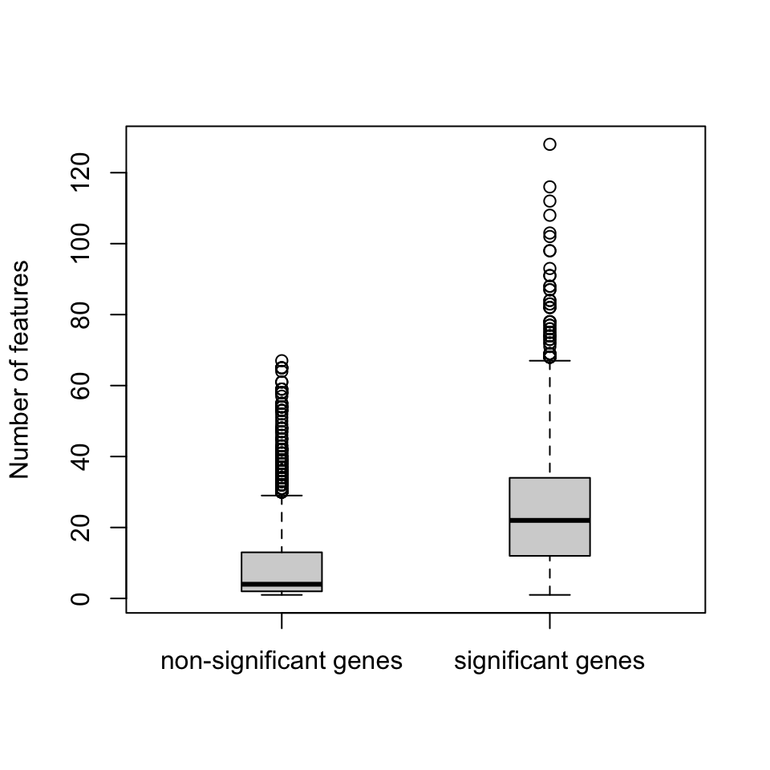

```r
lrTestBias(gene.based.table,boxplot.width=0.3)
```

To perform pathway analysis that adjusts for the number of gene features, we use the **runPathwangSplice** function, which implements the methodology described in [@Young2010]. **runPathwangSplice** returns a [tibble](https://cran.r-project.org/web/packages/tibble/vignettes/tibble.html) dataset with statistical significance of the pathway (`over_represented_pvalue`), as well as the significant genes that drives pathway significance (`SIGgene_ensembl` and `SIGgene_symbol`). An additional bias plot that visualizes the relationship between the proportion of significant genes and the mean number of gene features within gene bins is also generated.

```r
result.adjusted <- runPathwaySplice(gene.based.table,genome='hg19',
                        id='ensGene',
                        test.cats=c('GO:BP'),
                        go.size.limit=c(5,30),method='Wallenius')
```

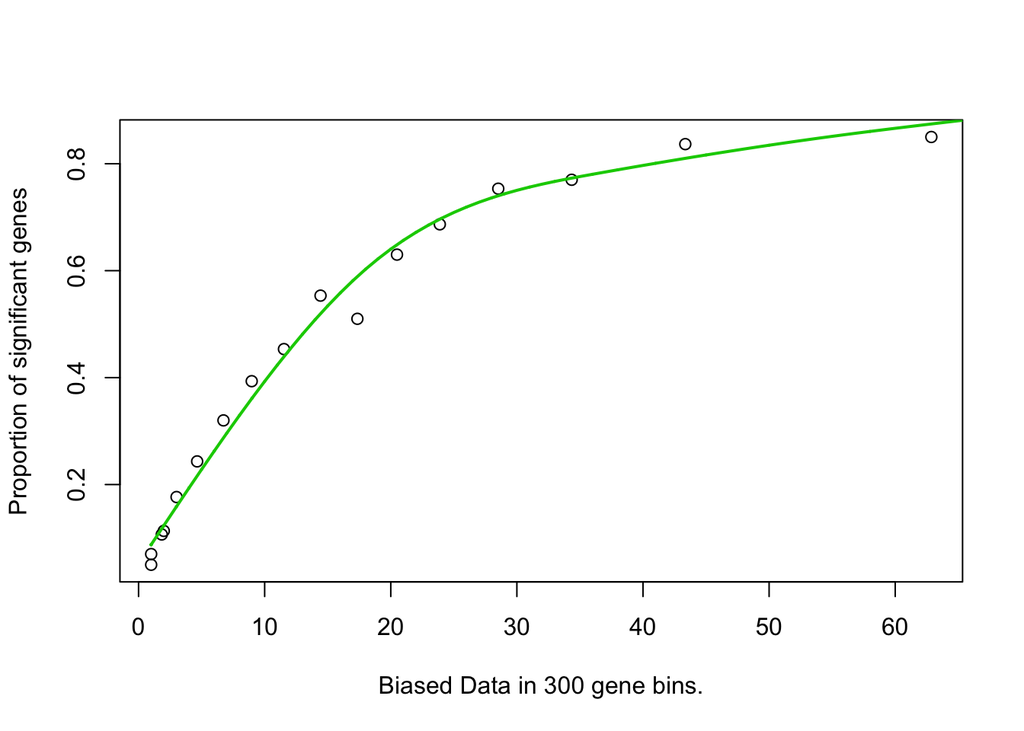

```r
head(result.adjusted)
```

```
#> # A tibble: 6 x 12
#>     gene_set over_represented_pvalue under_represented_pvalue numSIGInCat
#>        <chr>                   <dbl>                    <dbl>       <int>
#> 1 GO:0043044             0.003587014                0.9996795          17
#> 2 GO:0006323             0.003660353                0.9994637          19
#> 3 GO:0006721             0.007491169                0.9993466          10
#> 4 GO:0006338             0.010590403                0.9969542          25
#> 5 GO:0016101             0.011808138                0.9989078           9
#> 6 GO:0006720             0.011840285                0.9981355          12
#> # ... with 8 more variables: numInCat <int>, description <chr>,
#> #   ontology <chr>, SIGgene_ensembl <list>, SIGgene_symbol <list>,
#> #   All_gene_ensembl <list>, All_gene_symbol <list>,
#> #   Ave_value_all_gene <dbl>
```

To performe pathway analysis for other user defined databases, one needs to specify the pathway database in [.gmt format](http://software.broadinstitute.org/cancer/software/gsea/wiki/index.php/Data_formats) first and then use the `gmtGene2Cat` function before calling `pathwaySplice` function.

```r
dir.name <- system.file('extdata', package='PathwaySplice')
hallmark.local.pathways <- file.path(dir.name,'h.all.v6.0.symbols.gmt.txt')
hlp <- gmtGene2Cat(hallmark.local.pathways, genomeID='hg19')
result.hallmark <- runPathwaySplice(gene.based.table,genome='hg19',id='ensGene',
                gene2cat=hlp, go.size.limit=c(5,200), method='Wallenius', binsize=20)
```

For example, the results for the MSigDB Hallmark gene sets are

```r
head(result.hallmark)
```

```
#> # A tibble: 6 x 10
#>                   gene_set over_represented_pvalue
#>                      <chr>                   <dbl>
#> 1  HALLMARK_MYC_TARGETS_V1             0.004980504
#> 2      HALLMARK_MYOGENESIS             0.082904236
#> 3  HALLMARK_G2M_CHECKPOINT             0.137421221
#> 4 HALLMARK_HEME_METABOLISM             0.154964914
#> 5 HALLMARK_APICAL_JUNCTION             0.199372916
#> 6 HALLMARK_MITOTIC_SPINDLE             0.212276966
#> # ... with 8 more variables: under_represented_pvalue <dbl>,
#> #   numSIGInCat <int>, numInCat <int>, SIGgene_ensembl <list>,
#> #   SIGgene_symbol <list>, All_gene_ensembl <list>,
#> #   All_gene_symbol <list>, Ave_value_all_gene <dbl>
```

Lastly, to visualize pathway analysis results in an enrichment network, we use the **enrichmentMap** function:

```r
output.file.dir <- file.path("~/PathwaySplice_output")
enmap <- enrichmentMap(result.adjusted,n=5,
                       output.file.dir=output.file.dir,
                       similarity.threshold=0.3, scaling.factor = 2)
```

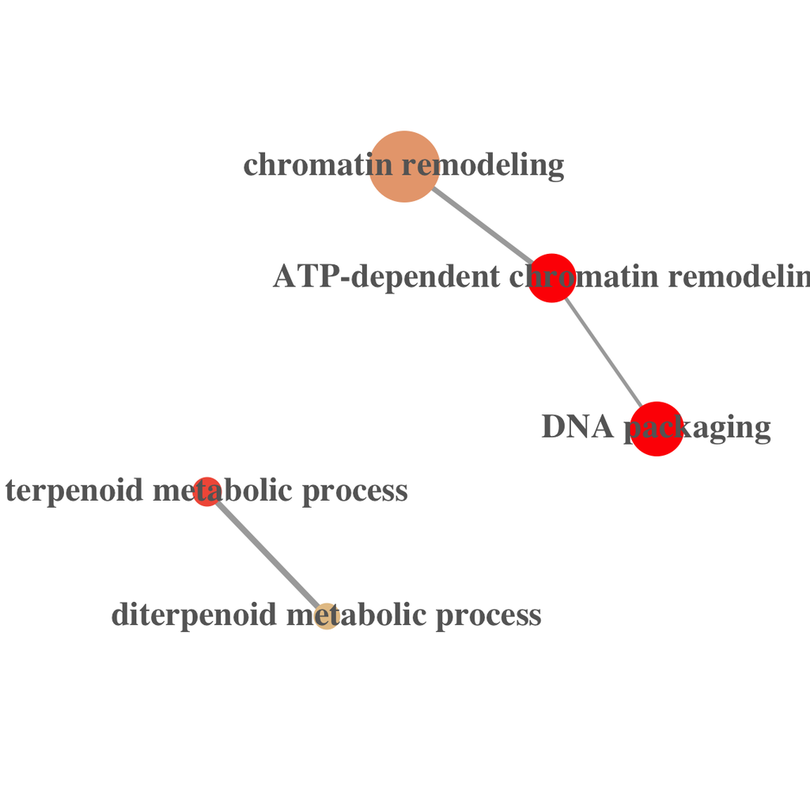

In the enrichment map, the `size of the nodes` indicates the number of significant genes within the pathway. The `color of the nodes` indicates pathway significance, where smaller p-values correspond to dark red color. Pathways with Jaccard coefficient > `similarity.thereshold` will be connected on the network. The `thickness of the edges` corresponds to Jaccard similarity coefficient between the two pathways, scaled by `scaling.factor`. A file named “network.layout.for.cytoscape.gml” is generated in the “~/PathwaySplice_output” directory. This file can be used as an input file for cytoscape software[@Shannon2003], which allows users to further maually adjust appearance of the generated network.